# Retail Strategy and Analytics

Krithika HJ

15 July 2021

## Load libraries and datasets

```r
library(readxl)
library(tidyverse)
```

```r
library(ggplot2)
library(readr)
library(data.table)
QVI_Purchase_Behavior <- read_csv("QVI_purchase_behaviour.csv")
QVI_Transaction_Data <- read_excel("QVI_transaction_data.xlsx", sheet = 1)
```

## Exlporatory Data Analysis

Let us first look at the structure of the data. ### Examining transaction data

```r
str(QVI_Transaction_Data)
```

```
## tibble [264,836 x 8] (S3: tbl_df/tbl/data.frame)
##  $ DATE          : num [1:264836] 43390 43599 43605 43329 43330 ...
##  $ STORE_NBR     : num [1:264836] 1 1 1 2 2 4 4 4 5 7 ...
##  $ LYLTY_CARD_NBR: num [1:264836] 1000 1307 1343 2373 2426 ...
##  $ TXN_ID        : num [1:264836] 1 348 383 974 1038 ...
##  $ PROD_NBR      : num [1:264836] 5 66 61 69 108 57 16 24 42 52 ...
##  $ PROD_NAME     : chr [1:264836] "Natural Chip        Compny SeaSalt175g" "CCs Nacho Cheese    175g" "Smiths Crinkle Cut  Chips Chicken 170g" "Smiths Chip Thinly  S/Cream&Onion 175g" ...
##  $ PROD_QTY      : num [1:264836] 2 3 2 5 3 1 1 1 1 2 ...
##  $ TOT_SALES     : num [1:264836] 6 6.3 2.9 15 13.8 5.1 5.7 3.6 3.9 7.2 ...
```

We can see that the date column is in an integer format. Let's change this to a date format.

```r
QVI_Transaction_Data$DATE <- as.Date(QVI_Transaction_Data$DATE, origin = "1899-12-30")
```

We are only interested in the Chips category, so let us examine products.

### Examine PROD_NAME

```r
productWords <- QVI_Transaction_Data$PROD_NAME %>% unique()
print(productWords)
```

```
##   [1] "Natural Chip        Compny SeaSalt175g"
##   [2] "CCs Nacho Cheese    175g"
##   [3] "Smiths Crinkle Cut  Chips Chicken 170g"
##   [4] "Smiths Chip Thinly  S/Cream&Onion 175g"
##   [5] "Kettle Tortilla ChpsHny&Jlpno Chili 150g"
##   [6] "Old El Paso Salsa   Dip Tomato Mild 300g"
##   [7] "Smiths Crinkle Chips Salt & Vinegar 330g"
##   [8] "Grain Waves         Sweet Chilli 210g"
##   [9] "Doritos Corn Chip Mexican Jalapeno 150g"
##  [10] "Grain Waves Sour    Cream&Chives 210G"
##  [11] "Kettle Sensations   Siracha Lime 150g"
##  [12] "Twisties Cheese     270g"
##  [13] "WW Crinkle Cut      Chicken 175g"
##  [14] "Thins Chips Light&  Tangy 175g"
##  [15] "CCs Original 175g"
```

[output cut: 99 more lines]

```r
remove_digits<- gsub("[0-9]+(g|G)", "", productWords)
remove_special <- gsub("&|/", "", remove_digits)
words<- unlist(strsplit(remove_special, " "))
df <- data.frame(words)
print(df)
```

```
##                 words
## 1             Natural
## 2                Chip
## 3
## 4
## 5
## 6
## 7
## 8
## 9
## 10             Compny
## 11            SeaSalt
## 12                CCs
## 13              Nacho
## 14             Cheese
## 15
## 16
## 17
## 18             Smiths
## 19            Crinkle
## 20                Cut
## 21
## 22              Chips
## 23            Chicken
## 24             Smiths
## 25               Chip
## 26             Thinly
## 27
## 28        SCreamOnion
## 29             Kettle
## 30           Tortilla
## 31       ChpsHnyJlpno
## 32              Chili
## 33                Old
## 34                 El
## 35               Paso
## 36              Salsa
## 37
## 38
## 39                Dip
```

[output cut: 663 more lines]

```
## 703              Salt
## 704
## 705
## 706
## 707
## 708             Smith
## 709           Crinkle
## 710               Cut
## 711
## 712
## 713         Bolognese
## 714           Doritos
## 715             Salsa
## 716              Mild
## 717
```

Summarise different types of words and their frequency

```r
freq_words <- df %>% count(words)
print(typeof(freq_words))
```

```
## [1] "list"
```

```r
unique_words <- freq_words[order(-freq_words$n),]
unique_words <- unique_words[-1,]
print(unique_words)
```

```
##                 words  n
## 35              Chips 21
## 148            Smiths 16
## 54            Crinkle 14
## 61                Cut 14
## 88             Kettle 13
## 23             Cheese 12
## 136              Salt 12
## 112          Original 10
## 32               Chip  9
## 66            Doritos  9
## 135             Salsa  9
## 26            Chicken  8
## 50               Corn  8
## 126          Pringles  8
```

[output cut: 179 more lines]

```r
#TransactionData <- QVI_Transaction_Data[!grepl("salsa",tolower(QVI_Transaction_Data$PROD_NAME)),]
#head(TransactionData)
TransactionData <- QVI_Transaction_Data
```

### Summarise features in transcation data; Check for nulls and outliers

```r
#Summarise the product quantity
summary(TransactionData)
```

```
##       DATE              STORE_NBR     LYLTY_CARD_NBR        TXN_ID
##  Min.   :2018-07-01   Min.   :  1.0   Min.   :   1000   Min.   :      1
##  1st Qu.:2018-09-30   1st Qu.: 70.0   1st Qu.:  70021   1st Qu.:  67602
##  Median :2018-12-30   Median :130.0   Median : 130358   Median : 135138
##  Mean   :2018-12-30   Mean   :135.1   Mean   : 135550   Mean   : 135158
##  3rd Qu.:2019-03-31   3rd Qu.:203.0   3rd Qu.: 203094   3rd Qu.: 202701
##  Max.   :2019-06-30   Max.   :272.0   Max.   :2373711   Max.   :2415841
##     PROD_NBR       PROD_NAME            PROD_QTY         TOT_SALES
##  Min.   :  1.00   Length:264836      Min.   :  1.000   Min.   :  1.500
##  1st Qu.: 28.00   Class :character   1st Qu.:  2.000   1st Qu.:  5.400
##  Median : 56.00   Mode  :character   Median :  2.000   Median :  7.400
##  Mean   : 56.58                      Mean   :  1.907   Mean   :  7.304
##  3rd Qu.: 85.00                      3rd Qu.:  2.000   3rd Qu.:  9.200
##  Max.   :114.00                      Max.   :200.000   Max.   :650.000
```

```r
#Check for null
TransactionData[is.null(TransactionData)]
```

```
## # A tibble: 264,836 x 0
```

```r
TransactionData[is.na(TransactionData)]
```

```
## <unspecified> [0]
```

There are no nulls, but it is clear that there are outliers present. We will investigate the values of the outliers.

```r
filter(TransactionData, TransactionData$PROD_QTY == 200)
```

```
## # A tibble: 2 x 8
##   DATE       STORE_NBR LYLTY_CARD_NBR TXN_ID PROD_NBR PROD_NAME         PROD_QTY
##   <date>         <dbl>          <dbl>  <dbl>    <dbl> <chr>                <dbl>
## 1 2018-08-19       226         226000 226201        4 Dorito Corn Chp ~      200
## 2 2019-05-20       226         226000 226210        4 Dorito Corn Chp ~      200
## # ... with 1 more variable: TOT_SALES <dbl>
```

This was bought by the same customer, let us investigate further into the transactions by this customer.

```r
filter(TransactionData, TransactionData$LYLTY_CARD_NBR == 226000)
```

```
## # A tibble: 2 x 8
##   DATE       STORE_NBR LYLTY_CARD_NBR TXN_ID PROD_NBR PROD_NAME         PROD_QTY
##   <date>         <dbl>          <dbl>  <dbl>    <dbl> <chr>                <dbl>
## 1 2018-08-19       226         226000 226201        4 Dorito Corn Chp ~      200
## 2 2019-05-20       226         226000 226210        4 Dorito Corn Chp ~      200
## # ... with 1 more variable: TOT_SALES <dbl>
```

This customer has only had the two transactions over the year and is not an ordinary retail customer. The customer might be buying chips for commercial purposes instead. We will remove this loyalty card number from further analysis.

```r
TransactionData <- TransactionData[!(TransactionData$LYLTY_CARD_NBR ==226000),]
#### Re-examine transaction data
summary(TransactionData)
```

```
##       DATE              STORE_NBR     LYLTY_CARD_NBR        TXN_ID
##  Min.   :2018-07-01   Min.   :  1.0   Min.   :   1000   Min.   :      1
##  1st Qu.:2018-09-30   1st Qu.: 70.0   1st Qu.:  70021   1st Qu.:  67601
##  Median :2018-12-30   Median :130.0   Median : 130357   Median : 135137
##  Mean   :2018-12-30   Mean   :135.1   Mean   : 135549   Mean   : 135158
##  3rd Qu.:2019-03-31   3rd Qu.:203.0   3rd Qu.: 203094   3rd Qu.: 202700
##  Max.   :2019-06-30   Max.   :272.0   Max.   :2373711   Max.   :2415841
##     PROD_NBR       PROD_NAME            PROD_QTY       TOT_SALES
##  Min.   :  1.00   Length:264834      Min.   :1.000   Min.   : 1.500
##  1st Qu.: 28.00   Class :character   1st Qu.:2.000   1st Qu.: 5.400
##  Median : 56.00   Mode  :character   Median :2.000   Median : 7.400
##  Mean   : 56.58                      Mean   :1.906   Mean   : 7.299
##  3rd Qu.: 85.00                      3rd Qu.:2.000   3rd Qu.: 9.200
##  Max.   :114.00                      Max.   :5.000   Max.   :29.500
```

Reexamine the data

```r
summary(TransactionData$PROD_QTY)
```

```
##    Min. 1st Qu.  Median    Mean 3rd Qu.    Max.
##   1.000   2.000   2.000   1.906   2.000   5.000
```

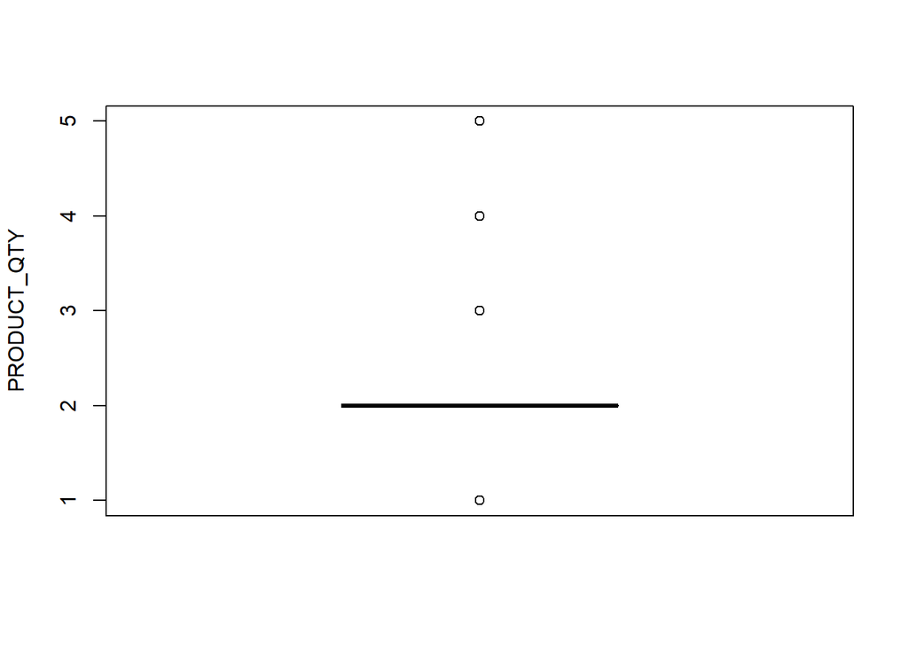

```r
boxplot(TransactionData$PROD_QTY, ylab="PRODUCT_QTY")
```

Let us view the transcations over time to see if there are any missing values.

```r
TransactionData %>% count(DATE)
```

```
## # A tibble: 364 x 2
##    DATE           n
##    <date>     <int>
##  1 2018-07-01   724
##  2 2018-07-02   711
##  3 2018-07-03   722
##  4 2018-07-04   714
##  5 2018-07-05   712
##  6 2018-07-06   762
##  7 2018-07-07   750
##  8 2018-07-08   696
##  9 2018-07-09   749
## 10 2018-07-10   705
## # ... with 354 more rows
```

```r
summary(TransactionData$DATE)
```

```
##         Min.      1st Qu.       Median         Mean      3rd Qu.         Max.
## "2018-07-01" "2018-09-30" "2018-12-30" "2018-12-30" "2019-03-31" "2019-06-30"
```

Since there are only 364 days, we are missing a day. Let us find which day that is by plotting a line chart.

Create a sequence of days from 1st July 2018 to 30 June 2019

```r
allDates <- data.table(seq(as.Date("2018/07/01"), as.Date("2019/06/30"), by ="day"))
setnames(allDates, "DATE")

Missing_transaction_data <- merge(allDates, TransactionData, by="DATE", all.x = TRUE)
Missing_day <- Missing_transaction_data[is.na(Missing_transaction_data$TOT_SALES),]
print(Missing_day)
```

```
##          DATE STORE_NBR LYLTY_CARD_NBR TXN_ID PROD_NBR PROD_NAME PROD_QTY
## 1: 2018-12-25        NA             NA     NA       NA      <NA>       NA
##    TOT_SALES
## 1:        NA
```

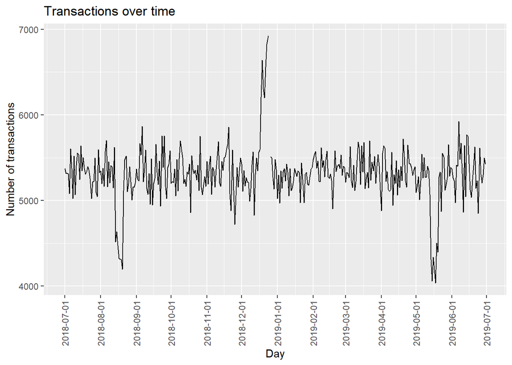

```r
Missing_Date <- Missing_transaction_data %>% group_by(DATE) %>% summarise(n=sum(TOT_SALES))

ggplot(Missing_Date, aes(x = DATE, y = n)) + geom_line()  + scale_x_date(breaks = "1 month") +
theme(axis.text.x = element_text(angle = 90, vjust = 0.5)) +
labs(x = "Day", y = "Number of transactions", title = "Transactions over time")
```

We can see that there is an increase in purchases in December and a break in late December. Let's zoom in on this.

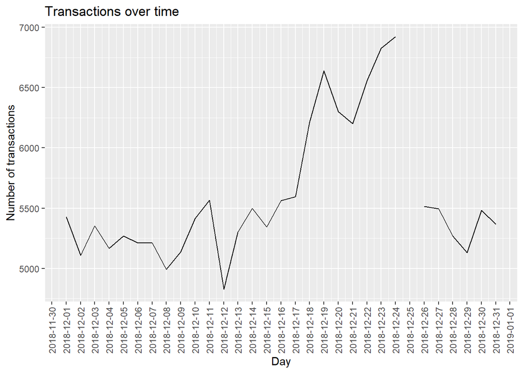

```r
December_Data <- Missing_transaction_data %>% filter(DATE >= "2018-12-01" & DATE < "2019-01-01")
December_Data <- December_Data %>% group_by(DATE) %>% summarise(N=sum(TOT_SALES))

ggplot(December_Data, aes(x = DATE, y = N))+geom_line() + labs(x = "Day", y = "Number of transactions", title = "Transactions over time") + scale_x_date(breaks = "1 day") + theme(axis.text.x = element_text(angle =90, vjust = 0.5))
```

```r
Missing_transaction_data[Missing_transaction_data$DATE == "2018-12-25",]
```

```
##          DATE STORE_NBR LYLTY_CARD_NBR TXN_ID PROD_NBR PROD_NAME PROD_QTY
## 1: 2018-12-25        NA             NA     NA       NA      <NA>       NA
##    TOT_SALES
## 1:        NA
```

We can see that the increase in sales occurs in the lead-up to Christmas and that there are zero sales on Christmas day itself. This is due to shops being closed on Christmas day.

Let us start creating other features such as brand of chips or pack size from PROD_NAME. ### PACK SIZE

```r
TransactionData$PACK_SIZE <- parse_number(TransactionData$PROD_NAME)
summary(TransactionData$PACK_SIZE)
```

```
##    Min. 1st Qu.  Median    Mean 3rd Qu.    Max.
##    70.0   150.0   170.0   182.4   175.0   380.0
```

The largest size is 380g and the smallest size is 70g - seems okay!

Let's plot a histogram of PACK_SIZE since we know that it is a categorical variable.

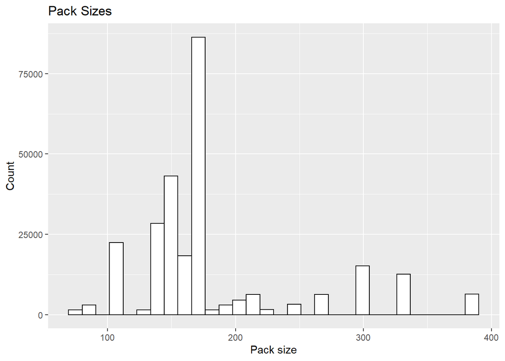

```r
ggplot(TransactionData, aes(x=PACK_SIZE)) + geom_histogram(color="black", fill="white") + labs(y = "Count", x = "Pack size", title = "Pack Sizes")
```

```r
TransactionData %>% count(PACK_SIZE) %>% arrange(desc(n))
```

```
## # A tibble: 21 x 2
##    PACK_SIZE     n
##        <dbl> <int>
##  1       175 66390
##  2       150 43131
##  3       134 25102
##  4       110 22387
##  5       170 19983
##  6       165 15297
##  7       300 15166
##  8       330 12540
##  9       380  6416
## 10       270  6285
## # ... with 11 more rows
```

These results look sensible with 175g being the most frequently sold item.

### BRAND NAME

```r
TransactionData$BRAND_NAME<-gsub("([A-Za-z]+).*", "\\1", TransactionData$PROD_NAME)
unique(TransactionData$BRAND_NAME)
```

```
##  [1] "Natural"    "CCs"        "Smiths"     "Kettle"     "Old"
##  [6] "Grain"      "Doritos"    "Twisties"   "WW"         "Thins"
## [11] "Burger"     "NCC"        "Cheezels"   "Infzns"     "Red"
## [16] "Pringles"   "Dorito"     "Infuzions"  "Smith"      "GrnWves"
## [21] "Tyrrells"   "Cobs"       "Woolworths" "French"     "RRD"
## [26] "Tostitos"   "Cheetos"    "Snbts"      "Sunbites"
```

```r
TransactionData %>% filter(BRAND_NAME == "Red")
```

```
## # A tibble: 5,885 x 10
##    DATE       STORE_NBR LYLTY_CARD_NBR TXN_ID PROD_NBR PROD_NAME        PROD_QTY
##    <date>         <dbl>          <dbl>  <dbl>    <dbl> <chr>               <dbl>
##  1 2018-08-15        41          41486  38472       13 Red Rock Deli T~        1
##  2 2019-05-20        45          45127  41122       64 Red Rock Deli S~        2
##  3 2018-08-16        51          51100  46802       48 Red Rock Deli S~        1
##  4 2018-08-19       257         257168 256776       64 Red Rock Deli S~        2
##  5 2019-03-13         1           1348    391       48 Red Rock Deli S~        1
##  6 2019-06-08         2           2203    806       64 Red Rock Deli S~        1
##  7 2018-07-07         5           5026   4524       13 Red Rock Deli T~        2
##  8 2019-03-30         5           5050   4671       64 Red Rock Deli S~        2
##  9 2018-12-14         5           5136   5176       48 Red Rock Deli S~        2
## 10 2018-10-17         9           9450   8955       64 Red Rock Deli S~        1
## # ... with 5,875 more rows, and 3 more variables: TOT_SALES <dbl>,
## #   PACK_SIZE <dbl>, BRAND_NAME <chr>
```

```r
TransactionData %>% filter(BRAND_NAME == "RRD")
```

```
## # A tibble: 11,894 x 10
##    DATE       STORE_NBR LYLTY_CARD_NBR TXN_ID PROD_NBR PROD_NAME        PROD_QTY
##    <date>         <dbl>          <dbl>  <dbl>    <dbl> <chr>               <dbl>
##  1 2019-05-18       120         120226 123743       67 RRD Chilli&    ~        1
##  2 2019-05-19       164         164183 164919       67 RRD Chilli&    ~        1
##  3 2018-08-16       191         191200 192940       53 RRD Sweet Chill~        1
##  4 2019-01-17         5           5018   4467       53 RRD Sweet Chill~        2
##  5 2018-08-11         5           5028   4535       67 RRD Chilli&    ~        2
##  6 2019-03-09         5           5050   4670       67 RRD Chilli&    ~        2
##  7 2018-07-11         5           5115   5031      103 RRD Steak &    ~        2
##  8 2019-02-07         5           5115   5035       85 RRD Honey Soy  ~        2
##  9 2019-06-16         6           6005   5770       97 RRD Salt & Vine~        1
## 10 2018-12-09         6           6382   6169       85 RRD Honey Soy  ~        1
## # ... with 11,884 more rows, and 3 more variables: TOT_SALES <dbl>,
## #   PACK_SIZE <dbl>, BRAND_NAME <chr>
```

Some of the brand names look like they are of the same brands - such as RED and RRD, which are both Red Rock Deli chips. Replace to make it similar.

```r
TransactionData$BRAND_NAME <- replace(TransactionData$BRAND_NAME, TransactionData$BRAND_NAME=="Red", "RRD")
unique(TransactionData$BRAND_NAME)
```

```
##  [1] "Natural"    "CCs"        "Smiths"     "Kettle"     "Old"
##  [6] "Grain"      "Doritos"    "Twisties"   "WW"         "Thins"
## [11] "Burger"     "NCC"        "Cheezels"   "Infzns"     "RRD"
## [16] "Pringles"   "Dorito"     "Infuzions"  "Smith"      "GrnWves"
## [21] "Tyrrells"   "Cobs"       "Woolworths" "French"     "Tostitos"
## [26] "Cheetos"    "Snbts"      "Sunbites"
```

## EXPLORE CUSTOMER DATASET

```r
str(QVI_Purchase_Behavior)
```

```
## spec_tbl_df [72,637 x 3] (S3: spec_tbl_df/tbl_df/tbl/data.frame)
##  $ LYLTY_CARD_NBR  : num [1:72637] 1000 1002 1003 1004 1005 ...
##  $ LIFESTAGE       : chr [1:72637] "YOUNG SINGLES/COUPLES" "YOUNG SINGLES/COUPLES" "YOUNG FAMILIES" "OLDER SINGLES/COUPLES" ...
##  $ PREMIUM_CUSTOMER: chr [1:72637] "Premium" "Mainstream" "Budget" "Mainstream" ...
##  - attr(*, "spec")=
##   .. cols(
##   ..   LYLTY_CARD_NBR = col_double(),
##   ..   LIFESTAGE = col_character(),
##   ..   PREMIUM_CUSTOMER = col_character()
##   .. )
```

Summary statistics for Lifestage and Premium Customer

```r
QVI_Purchase_Behavior %>% count(LIFESTAGE)
```

```
## # A tibble: 7 x 2
##   LIFESTAGE                  n
##   <chr>                  <int>
## 1 MIDAGE SINGLES/COUPLES  7275
## 2 NEW FAMILIES            2549
## 3 OLDER FAMILIES          9780
## 4 OLDER SINGLES/COUPLES  14609
## 5 RETIREES               14805
## 6 YOUNG FAMILIES          9178
## 7 YOUNG SINGLES/COUPLES  14441
```

```r
QVI_Purchase_Behavior %>% count(PREMIUM_CUSTOMER)
```

```
## # A tibble: 3 x 2
##   PREMIUM_CUSTOMER     n
##   <chr>            <int>
## 1 Budget           24470
## 2 Mainstream       29245
## 3 Premium          18922
```

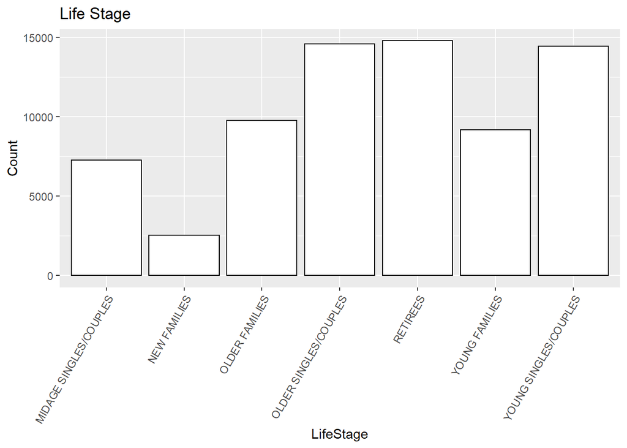

```r
ggplot(QVI_Purchase_Behavior, aes(x=LIFESTAGE)) + geom_bar(color="black", fill="white") + labs(y = "Count", x = "LifeStage", title = "Life Stage") + theme(axis.text.x = element_text(angle = 60, hjust = 1))
```

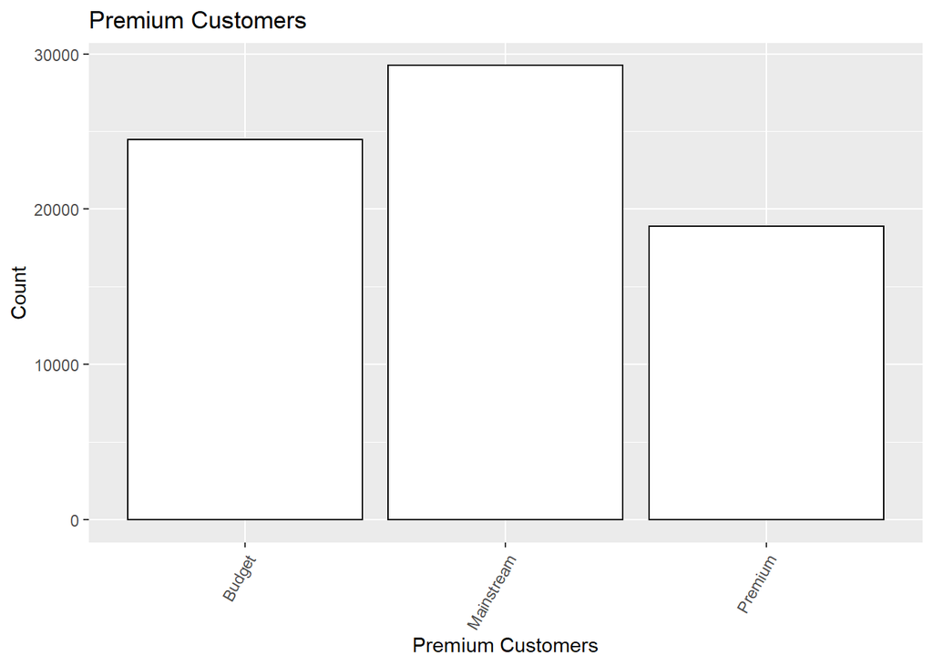

```r
ggplot(QVI_Purchase_Behavior, aes(x=PREMIUM_CUSTOMER)) + geom_bar(color="black", fill="white") + labs(y = "Count", x = "Premium Customers", title = "Premium Customers") + theme(axis.text.x = element_text(angle = 60, hjust = 1))
```

These results seem normal.

We must merge the two databases.

```r
Retail_Data <- merge(QVI_Purchase_Behavior, QVI_Transaction_Data, by="LYLTY_CARD_NBR", all=TRUE)
head(Retail_Data)
```

```
##   LYLTY_CARD_NBR              LIFESTAGE PREMIUM_CUSTOMER       DATE STORE_NBR
## 1           1000  YOUNG SINGLES/COUPLES          Premium 2018-10-17         1
## 2           1002  YOUNG SINGLES/COUPLES       Mainstream 2018-09-16         1
## 3           1003         YOUNG FAMILIES           Budget 2019-03-08         1
## 4           1003         YOUNG FAMILIES           Budget 2019-03-07         1
## 5           1004  OLDER SINGLES/COUPLES       Mainstream 2018-11-02         1
## 6           1005 MIDAGE SINGLES/COUPLES       Mainstream 2018-12-28         1
##   TXN_ID PROD_NBR                              PROD_NAME PROD_QTY TOT_SALES
## 1      1        5 Natural Chip        Compny SeaSalt175g        2       6.0
## 2      2       58  Red Rock Deli Chikn&Garlic Aioli 150g        1       2.7
## 3      4      106 Natural ChipCo      Hony Soy Chckn175g        1       3.0
## 4      3       52  Grain Waves Sour    Cream&Chives 210G        1       3.6
## 5      5       96         WW Original Stacked Chips 160g        1       1.9
## 6      6       86                     Cheetos Puffs 165g        1       2.8
```

```r
Retail_Data_Chips <- Retail_Data[!grepl("salsa",tolower(Retail_Data$PROD_NAME)),]
```

Check for Null values:

```r
Retail_Data[is.na(Retail_Data)]
```

```
## character(0)
```

```r
Retail_Data_Chips[is.na(Retail_Data_Chips)]
```

```
## character(0)
```

As there are no null values, save the new dataset.

```r
write_csv(Retail_Data,"QVI_data.csv")
```

```r
write_csv(Retail_Data_Chips, "QVI_data_chips.csv")
```

## DATA ANALYSIS

Now that the data is ready for analysis, we can define some metrics of interest to the client:

#### 1. Total sales for each customer segment.

```r
Premium_Customer <- Retail_Data_Chips %>% group_by(PREMIUM_CUSTOMER) %>% summarise(Total_Sales = sum(TOT_SALES)) %>% arrange(desc(Total_Sales))
print(Premium_Customer)
```

```
## # A tibble: 3 x 2
##   PREMIUM_CUSTOMER Total_Sales
##   <chr>                  <dbl>
## 1 Mainstream           700865.
## 2 Budget               631407.
## 3 Premium              474205.
```

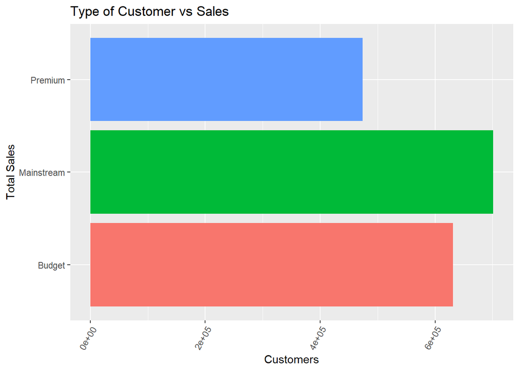

```r
ggplot(Premium_Customer, aes (x=PREMIUM_CUSTOMER, y=Total_Sales, fill=PREMIUM_CUSTOMER)) + geom_bar(stat = "identity") +
  theme(legend.position="none") + coord_flip() + theme(axis.text.x = element_text(angle = 60, hjust = 1))  + labs(y = "Customers", x = "Total Sales", title = "Type of Customer vs Sales")
```

It seems that mainstream customers drive the sales.

#### 2. Total sales by life stage

```r
Retail_Data_Chips %>% group_by(LIFESTAGE) %>% summarise(Total_Sales = sum(TOT_SALES)) %>% arrange(desc(Total_Sales))
```

```
## # A tibble: 7 x 2
##   LIFESTAGE              Total_Sales
##   <chr>                        <dbl>
## 1 OLDER SINGLES/COUPLES      376020.
## 2 RETIREES                   342382.
## 3 OLDER FAMILIES             329820.
## 4 YOUNG FAMILIES             294628.
## 5 YOUNG SINGLES/COUPLES      243757.
## 6 MIDAGE SINGLES/COUPLES     172524.
## 7 NEW FAMILIES                47348.
```

Older singles/couples spend more on chips. Let us see how premium customers are split by lifestage

```r
Customer_Seg <- Retail_Data_Chips %>% group_by(PREMIUM_CUSTOMER, LIFESTAGE) %>% summarise(Total_Sales = sum(TOT_SALES)) %>% arrange(desc(Total_Sales))
print(Customer_Seg)
```

```
## # A tibble: 21 x 3
## # Groups:   PREMIUM_CUSTOMER [3]
##    PREMIUM_CUSTOMER LIFESTAGE             Total_Sales
##    <chr>            <chr>                       <dbl>
##  1 Budget           OLDER FAMILIES            156864.
##  2 Mainstream       YOUNG SINGLES/COUPLES     147582.
##  3 Mainstream       RETIREES                  145169.
##  4 Budget           YOUNG FAMILIES            129718.
##  5 Budget           OLDER SINGLES/COUPLES     127834.
##  6 Mainstream       OLDER SINGLES/COUPLES     124648.
##  7 Premium          OLDER SINGLES/COUPLES     123538.
##  8 Budget           RETIREES                  105916.
##  9 Mainstream       OLDER FAMILIES             96414.
## 10 Premium          RETIREES                   91297.
## # ... with 11 more rows
```

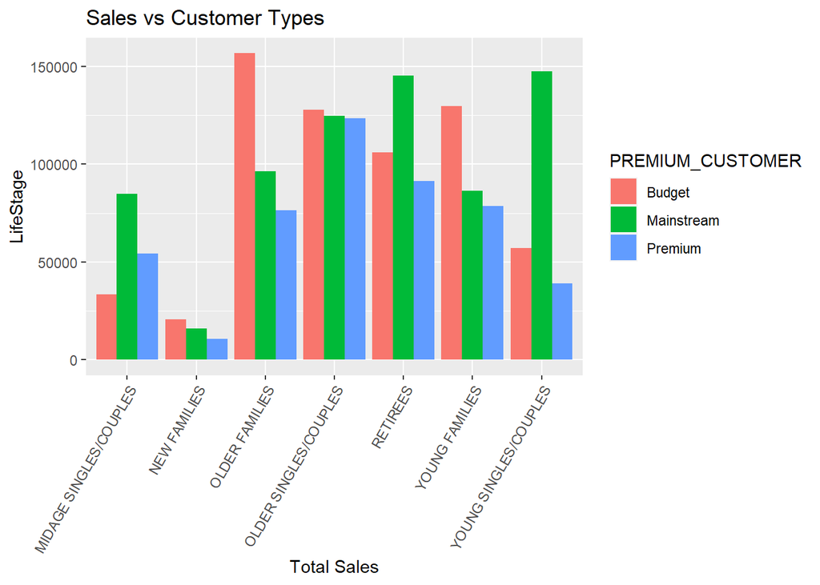

```r
options(repr.plot.width=10, repr.plot.height=8)
ggplot(Customer_Seg, aes (x=LIFESTAGE, y=Total_Sales, fill=PREMIUM_CUSTOMER)) + geom_bar(stat="identity",position = position_dodge()) +  theme(axis.text.x = element_text(angle = 60, hjust = 1))  + labs(y = "LifeStage", x = "Total Sales", title = "Sales vs Customer Types")
```

#### 3. Let us see what stores have the maximum sales.

```r
Retail_Data_Chips %>% group_by(STORE_NBR) %>% summarise(Total_Sales = sum(TOT_SALES)) %>% arrange(desc(Total_Sales))
```

```
## # A tibble: 271 x 2
##    STORE_NBR Total_Sales
##        <dbl>       <dbl>
##  1       226      17845.
##  2        88      15446.
##  3       165      15188.
##  4       237      14831.
##  5        40      14427.
##  6        58      14257.
##  7       199      13976.
##  8         4      13709.
##  9       203      13623.
## 10        26      13597.
## # ... with 261 more rows
```

This information helps us see that some stores outperform, where as others have really low sales. #### 4. Average chip price by customer segement

```r
Avg_Price_Seg <- Retail_Data_Chips %>% group_by(PREMIUM_CUSTOMER, LIFESTAGE) %>% summarise(Avg_Sales = mean(TOT_SALES)) %>% arrange(desc(Avg_Sales))
print(Avg_Price_Seg)
```

```
## # A tibble: 21 x 3
## # Groups:   PREMIUM_CUSTOMER [3]
##    PREMIUM_CUSTOMER LIFESTAGE              Avg_Sales
##    <chr>            <chr>                      <dbl>
##  1 Mainstream       MIDAGE SINGLES/COUPLES      7.64
##  2 Mainstream       YOUNG SINGLES/COUPLES       7.55
##  3 Premium          RETIREES                    7.46
##  4 Premium          OLDER SINGLES/COUPLES       7.46
##  5 Budget           RETIREES                    7.45
##  6 Budget           OLDER SINGLES/COUPLES       7.44
##  7 Premium          OLDER FAMILIES              7.36
##  8 Mainstream       NEW FAMILIES                7.31
##  9 Mainstream       OLDER SINGLES/COUPLES       7.31
## 10 Budget           YOUNG FAMILIES              7.30
## # ... with 11 more rows
```

We have also observed that highest sales are from ### 1. Budget- OLDER FAMILIES - 156863.75  
### 2. Mainstream - YOUNG SINGLES/COUPLES - 147582.20  
### 3. Mainstream - RETIREES - 145168.95

Average number of sales are higher among: ### 1.Mainstream - MIDAGE SINGLES/COUPLES - 7.637156  
### 2.Mainstreamv - YOUNG SINGLES/COUPLES - 7.551279  
### 3.Premium - RETIREES - 7.461315

#### 5. Number of customers in each segment

```r
Retail_Data_Chips %>% count(PREMIUM_CUSTOMER) %>% arrange(desc(n))
```

```
##   PREMIUM_CUSTOMER     n
## 1       Mainstream 95043
## 2           Budget 86762
## 3          Premium 64937
```

```r
Retail_Data_Chips %>% count(PREMIUM_CUSTOMER, LIFESTAGE) %>% arrange(desc(n))
```

```
##    PREMIUM_CUSTOMER              LIFESTAGE     n
## 1            Budget         OLDER FAMILIES 21514
## 2        Mainstream               RETIREES 19970
## 3        Mainstream  YOUNG SINGLES/COUPLES 19544
## 4            Budget         YOUNG FAMILIES 17763
## 5            Budget  OLDER SINGLES/COUPLES 17172
## 6        Mainstream  OLDER SINGLES/COUPLES 17061
## 7           Premium  OLDER SINGLES/COUPLES 16560
## 8            Budget               RETIREES 14225
## 9        Mainstream         OLDER FAMILIES 13241
## 10          Premium               RETIREES 12236
## 11       Mainstream         YOUNG FAMILIES 11947
## 12       Mainstream MIDAGE SINGLES/COUPLES 11095
## 13          Premium         YOUNG FAMILIES 10784
## 14          Premium         OLDER FAMILIES 10405
## 15           Budget  YOUNG SINGLES/COUPLES  8573
## 16          Premium MIDAGE SINGLES/COUPLES  7612
## 17          Premium  YOUNG SINGLES/COUPLES  5852
## 18           Budget MIDAGE SINGLES/COUPLES  4691
## 19           Budget           NEW FAMILIES  2824
## 20       Mainstream           NEW FAMILIES  2185
## 21          Premium           NEW FAMILIES  1488
```

It is clear mainstream sales are higher as there are more consumers in this segment. However, Budget older families have the highest customers.

Higher sales may also be driven by more units of chips being bought per customer. Let's have a look at this next.

```r
Avg_Qty_Seg <- Retail_Data_Chips %>% group_by(PREMIUM_CUSTOMER, LIFESTAGE) %>% summarise(Avg_Quantity = mean(PROD_QTY)) %>% arrange(desc(Avg_Quantity))
print(Avg_Qty_Seg)
```

```
## # A tibble: 21 x 3
## # Groups:   PREMIUM_CUSTOMER [3]
##    PREMIUM_CUSTOMER LIFESTAGE              Avg_Quantity
##    <chr>            <chr>                         <dbl>
##  1 Premium          OLDER FAMILIES                 1.98
##  2 Mainstream       OLDER FAMILIES                 1.95
##  3 Budget           OLDER FAMILIES                 1.95
##  4 Mainstream       YOUNG FAMILIES                 1.94
##  5 Budget           YOUNG FAMILIES                 1.94
##  6 Premium          YOUNG FAMILIES                 1.94
##  7 Budget           OLDER SINGLES/COUPLES          1.91
##  8 Premium          OLDER SINGLES/COUPLES          1.91
##  9 Mainstream       MIDAGE SINGLES/COUPLES         1.91
## 10 Mainstream       OLDER SINGLES/COUPLES          1.91
## # ... with 11 more rows
```

The average quantity sold is higer among: ### 1. Premium - OLDER FAMILIE - 1.983566  
### 2. Mainstream - OLDER FAMILIES - 1.948795 ### 3. Budget- OLDER FAMILIES - 1.945384

Let us look at the average price per chips by customer segments

```r
Avg_chips_Seg <- Retail_Data_Chips %>% group_by(PREMIUM_CUSTOMER, LIFESTAGE) %>% summarise(Avg_Price = mean(TOT_SALES/PROD_QTY)) %>% arrange(desc(Avg_Price))
print(Avg_chips_Seg)
```

```
## # A tibble: 21 x 3
## # Groups:   PREMIUM_CUSTOMER [3]
##    PREMIUM_CUSTOMER LIFESTAGE              Avg_Price
##    <chr>            <chr>                      <dbl>
##  1 Mainstream       YOUNG SINGLES/COUPLES       4.07
##  2 Mainstream       MIDAGE SINGLES/COUPLES      3.99
##  3 Budget           RETIREES                    3.92
##  4 Premium          RETIREES                    3.92
##  5 Budget           NEW FAMILIES                3.92
##  6 Mainstream       NEW FAMILIES                3.92
##  7 Premium          OLDER SINGLES/COUPLES       3.89
##  8 Budget           OLDER SINGLES/COUPLES       3.88
##  9 Premium          NEW FAMILIES                3.87
## 10 Mainstream       RETIREES                    3.84
## # ... with 11 more rows
```

Mainstream midage and young singles and couples are more willing to pay more per packet of chips compared to their budget and premium counterparts. This may be due to premium shoppers being more likely to buy healthy snacks and when they buy chips.This is also supported by there being fewer premium midage and young singles and couples buying chips compared to their mainstream counterparts.

As the difference in average price per unit isn't large, we can check if this difference is statistically different.

```r
Mainstream_Young <- Retail_Data_Chips %>% filter(PREMIUM_CUSTOMER == "Mainstream" & LIFESTAGE == "YOUNG SINGLES/COUPLES" | LIFESTAGE == "MIDAGE SINGLES/COUPLES")
Other <- Retail_Data_Chips %>% filter(PREMIUM_CUSTOMER != "Mainstream" & LIFESTAGE == "YOUNG SINGLES/COUPLES" | LIFESTAGE == "MIDAGE SINGLES/COUPLES")

t.test(Mainstream_Young$TOT_SALES, Other$TOT_SALES,alternative = "greater")
```

```
##
##  Welch Two Sample t-test
##
## data:  Mainstream_Young$TOT_SALES and Other$TOT_SALES
## t = 19.672, df = 78690, p-value < 2.2e-16
## alternative hypothesis: true difference in means is greater than 0
## 95 percent confidence interval:
##  0.3209958       Inf
## sample estimates:
## mean of x mean of y
##  7.454380  7.104095
```

The p-value shows the two distributions are significantly different.

Let us dive into the mainstream young couples segment.

Lets use brand_name and pack_size to determine if there is an affinity to particular brands.

```r
Retail_Data_Chips$PACK_SIZE<- parse_number(Retail_Data_Chips$PROD_NAME)
Retail_Data_Chips$BRAND <-gsub("([A-Za-z]+).*", "\\1", Retail_Data_Chips$PROD_NAME)
Retail_Data_Chips$BRAND <- replace(Retail_Data_Chips$BRAND, Retail_Data_Chips$BRAND=="Red", "RRD")
```

```r
head(Retail_Data_Chips)
```

```
##   LYLTY_CARD_NBR              LIFESTAGE PREMIUM_CUSTOMER       DATE STORE_NBR
## 1           1000  YOUNG SINGLES/COUPLES          Premium 2018-10-17         1
## 2           1002  YOUNG SINGLES/COUPLES       Mainstream 2018-09-16         1
## 3           1003         YOUNG FAMILIES           Budget 2019-03-08         1
## 4           1003         YOUNG FAMILIES           Budget 2019-03-07         1
## 5           1004  OLDER SINGLES/COUPLES       Mainstream 2018-11-02         1
## 6           1005 MIDAGE SINGLES/COUPLES       Mainstream 2018-12-28         1
##   TXN_ID PROD_NBR                              PROD_NAME PROD_QTY TOT_SALES
## 1      1        5 Natural Chip        Compny SeaSalt175g        2       6.0
## 2      2       58  Red Rock Deli Chikn&Garlic Aioli 150g        1       2.7
## 3      4      106 Natural ChipCo      Hony Soy Chckn175g        1       3.0
## 4      3       52  Grain Waves Sour    Cream&Chives 210G        1       3.6
## 5      5       96         WW Original Stacked Chips 160g        1       1.9
## 6      6       86                     Cheetos Puffs 165g        1       2.8
##   PACK_SIZE   BRAND
## 1       175 Natural
## 2       150     RRD
## 3       175 Natural
## 4       210   Grain
## 5       160      WW
## 6       165 Cheetos
```

#### 6. Let us see what brand sells the highest

```r
Retail_Data_Chips %>% filter(PREMIUM_CUSTOMER == "Mainstream", LIFESTAGE == "YOUNG SINGLES/COUPLES") %>% group_by(BRAND) %>% summarise(Total_Sales = sum(TOT_SALES)) %>% arrange(desc(Total_Sales))
```

```
## # A tibble: 27 x 2
##    BRAND     Total_Sales
##    <chr>           <dbl>
##  1 Kettle         35424.
##  2 Doritos        17266.
##  3 Pringles       16006.
##  4 Smiths         14338.
##  5 Twisties        7540.
##  6 Tostitos        7238
##  7 Thins           7217.
##  8 Infuzions       6694.
##  9 Cobs            6145.
## 10 Tyrrells        4801.
## # ... with 17 more rows
```

Kettle seems to have the highest sales, let us see among which segment these sales are high.

#### 7. Repeat for pack size.

```r
Retail_Data_Chips %>% filter (PREMIUM_CUSTOMER == "Mainstream", LIFESTAGE == "YOUNG SINGLES/COUPLES")%>% group_by(PACK_SIZE) %>% summarise(Total_Sales = sum(TOT_SALES)) %>% arrange(desc(Total_Sales))
```

```
## # A tibble: 20 x 2
##    PACK_SIZE Total_Sales
##        <dbl>       <dbl>
##  1       175      37968.
##  2       150      22946.
##  3       134      16006.
##  4       110      14630
##  5       330      12654
##  6       170      11893.
##  7       165       7395
##  8       380       7176.
##  9       270       5304.
## 10       210       3798
## 11       135       2247
## 12       250       2236
## 13       190        740.
## 14       200        618.
## 15       160        441.
## 16       180        403
## 17        90        391
## 18        70        264
## 19       220        244.
## 20       125        229.
```

175g seems to be the most commonly sold pack size.

#### 8. Let us check the average price per unit spent by every customer for brand and pack, how these two rank against each other and the customer.

```r
Retail_Data_Chips %>% filter(PREMIUM_CUSTOMER == "Mainstream", LIFESTAGE == "YOUNG SINGLES/COUPLES")%>% group_by(BRAND) %>% summarise(Avg_Price_Brand = mean(TOT_SALES/PROD_QTY)) %>% arrange(desc(Avg_Price_Brand))
```

```
## # A tibble: 27 x 2
##    BRAND    Avg_Price_Brand
##    <chr>              <dbl>
##  1 Dorito              6.39
##  2 Cheezels            5.09
##  3 Kettle              4.94
##  4 Twisties            4.51
##  5 Doritos             4.45
##  6 Tostitos            4.4
##  7 Smiths              4.38
##  8 Tyrrells            4.2
##  9 Cobs                3.8
## 10 Infzns              3.8
## # ... with 17 more rows
```

```r
Retail_Data_Chips %>% filter(PREMIUM_CUSTOMER == "Mainstream", LIFESTAGE == "YOUNG SINGLES/COUPLES") %>% group_by(PACK_SIZE) %>% summarise(Avg_Price_Pack = mean(TOT_SALES/PROD_QTY)) %>% arrange(desc(Avg_Price_Pack))
```

```
## # A tibble: 20 x 2
##    PACK_SIZE Avg_Price_Pack
##        <dbl>          <dbl>
##  1       380           6.14
##  2       330           5.7
##  3       270           4.6
##  4       250           4.3
##  5       135           4.2
##  6       175           4.10
##  7       170           4.05
##  8       150           4.01
##  9       110           3.8
## 10       134           3.7
## 11       165           3.66
## 12       210           3.6
## 13       180           3.1
## 14       190           2.73
## 15        70           2.4
## 16       220           2.3
## 17       125           2.1
## 18       160           1.9
## 19       200           1.9
## 20        90           1.7
```

```r
Retail_Data_Chips %>% filter(PREMIUM_CUSTOMER == "Mainstream", LIFESTAGE == "YOUNG SINGLES/COUPLES") %>% group_by(BRAND, PACK_SIZE) %>% summarise(Avg_Price = mean(TOT_SALES/PROD_QTY)) %>% arrange(desc(Avg_Price))
```

```
## # A tibble: 42 x 3
## # Groups:   BRAND [27]
##    BRAND    PACK_SIZE Avg_Price
##    <chr>        <dbl>     <dbl>
##  1 Dorito         380      6.39
##  2 Smiths         380      5.9
##  3 Cheezels       330      5.7
##  4 Doritos        330      5.7
##  5 Smiths         330      5.7
##  6 Kettle         175      5.4
##  7 Kettle         150      4.6
##  8 Twisties       270      4.6
##  9 Doritos        170      4.4
## 10 Tostitos       175      4.4
## # ... with 32 more rows
```

#### 8. Let us check the quantity bought by every customer for brand and pack, how these two rank against each other and the customer.

```r
Retail_Data_Chips %>% filter(PREMIUM_CUSTOMER == "Mainstream", LIFESTAGE == "YOUNG SINGLES/COUPLES") %>% group_by(BRAND) %>% summarise(Qty_brand= sum(PROD_QTY)) %>% arrange(desc(Qty_brand))
```

```
## # A tibble: 27 x 2
##    BRAND     Qty_brand
##    <chr>         <dbl>
##  1 Kettle         7172
##  2 Pringles       4326
##  3 Doritos        3878
##  4 Smiths         3252
##  5 Thins          2187
##  6 Infuzions      1802
##  7 Twisties       1673
##  8 Tostitos       1645
##  9 Cobs           1617
## 10 RRD            1587
## # ... with 17 more rows
```

```r
Retail_Data_Chips %>% filter(PREMIUM_CUSTOMER == "Mainstream", LIFESTAGE == "YOUNG SINGLES/COUPLES") %>% group_by(PACK_SIZE) %>% summarise(Qty_pack = sum(PROD_QTY)) %>% arrange(desc(Qty_pack))
```

```
## # A tibble: 20 x 2
##    PACK_SIZE Qty_pack
##        <dbl>    <dbl>
##  1       175     9237
##  2       150     5709
##  3       134     4326
##  4       110     3850
##  5       170     2926
##  6       330     2220
##  7       165     2016
##  8       380     1165
##  9       270     1153
## 10       210     1055
## 11       135      535
## 12       250      520
## 13       200      325
## 14       190      271
## 15       160      232
## 16        90      230
## 17       180      130
## 18        70      110
## 19       125      109
## 20       220      106
```

```r
DF <- data.frame(Retail_Data_Chips$LYLTY_CARD_NBR, Retail_Data_Chips$LIFESTAGE, Retail_Data_Chips$PREMIUM_CUSTOMER, Retail_Data_Chips$DATE, Retail_Data_Chips$STORE_NBR, Retail_Data_Chips$TXN_ID, Retail_Data_Chips$PROD_NBR, Retail_Data_Chips$PROD_NAME, Retail_Data_Chips$PROD_QTY, Retail_Data_Chips$TOT_SALES, Retail_Data_Chips$PACK_SIZE, Retail_Data_Chips$BRAND)
print(DF)
```

[output not shown]

[output cut: 29262 more lines]